# ALB analysis

## The ALB data

The ALB data are in the latest version, `6.0-10`, of the `gamlss.data` package. (Note that you may have to get the latest version of ther package from the [gamlss universe](https://gamlss-dev.r-universe.dev/builds) since it not to CRAN yet.

Getting the data from `gamlss.data`;

```r
library(gamlss)
data(ALB)
dim(ALB)
```

```
[1] 3429    2
```

```r
head(ALB)
```

```
   ALB   ga
1 42.1 12.1
2 42.4 11.6
3 43.8 12.7
4 40.3 12.5
5 44.0 12.0
6 44.4 12.9
```

Now we plot the data;

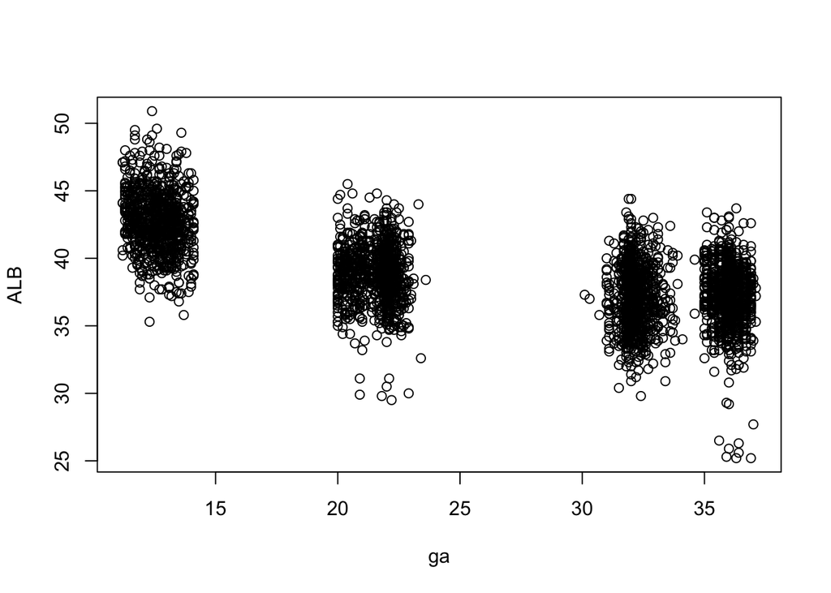

```r
plot(ALB~ga, data=ALB)
```

The data were collected when healthy pregnant woman had their scans at Kings College hospital. The scan are taken routinely four times. That explains why they are caps in data for different gestational age. Notice that ate this data they are NOT repeated observations, all 3429 women are different.

**Purpose**

The purpose of the study is to identify patients with low `ALB`

## Fit a model

Here we are using a `distributional regression` model, GAMLSS, to answer the question. In a distributional model all the parameters of the distributions are functions of the explanatory variables. Here we have only one gestation age, `ga`.

Any GAMLSS regression model needs two type of assumptions:

1. the assumed `distribution` for the response i.e `family=GA`,
2. the `selection` of covariates; In fact in general since we are modelling all distribution parameters as functions of the covariates, we are looking `which covariate` affect `which distribution parameter`.

To start a selection procedure in GAMLSS we need a starting model.

Here we fit two starting models;

1. a normal model e.g. `family=NO` which works as a staring model for the function `chooseDist()`

```r
m00 <- gamlss(   ALB ~ pb(ga),
    sigma.formula = ~ pb(ga),
      nu.formula = ~ pb(ga),
     tau.formula = ~ pb(ga),
             family = NO, data = ALB)
```

```
GAMLSS-RS iteration 1: Global Deviance = 15306.02
GAMLSS-RS iteration 2: Global Deviance = 15306.09
GAMLSS-RS iteration 3: Global Deviance = 15306.09
```

2. a BCTo model e.g. `family=BCTo` `which is used as staring model for the function`chooseDistCV()`(see note below for an explanation why we have to do that). The function`chooseDistCV()`is a new function and has to be sourced.

```r
m0 <- gamlss(   ALB ~ pb(ga),
    sigma.formula = ~ pb(ga),
      nu.formula = ~ pb(ga),
     tau.formula = ~ pb(ga),
             family = BCTo, data = ALB, n.cyc=100)
```

```
GAMLSS-RS iteration 1: Global Deviance = 15198.53
GAMLSS-RS iteration 2: Global Deviance = 15168.6
GAMLSS-RS iteration 3: Global Deviance = 15167.18
GAMLSS-RS iteration 4: Global Deviance = 15164.12
GAMLSS-RS iteration 5: Global Deviance = 15160.44
GAMLSS-RS iteration 6: Global Deviance = 15157.94
GAMLSS-RS iteration 7: Global Deviance = 15156.61
GAMLSS-RS iteration 8: Global Deviance = 15155.96
GAMLSS-RS iteration 9: Global Deviance = 15155.65
GAMLSS-RS iteration 10: Global Deviance = 15155.52
GAMLSS-RS iteration 11: Global Deviance = 15155.45
GAMLSS-RS iteration 12: Global Deviance = 15155.42
GAMLSS-RS iteration 13: Global Deviance = 15155.4
GAMLSS-RS iteration 14: Global Deviance = 15155.39
GAMLSS-RS iteration 15: Global Deviance = 15155.38
GAMLSS-RS iteration 16: Global Deviance = 15155.38
GAMLSS-RS iteration 17: Global Deviance = 15155.38
GAMLSS-RS iteration 18: Global Deviance = 15155.38
```

**reminder**

The `nu.formula = ~ pb(ga)` and `tau.formula = ~ pb(ga)` will be not be used by `chooseDistCV()` unless more that two parameter are involved in the distribution. This has to be investigated further.

**reminder**

I have to find out why the function `chooseDistCV()` do not accepts the normal error model like `chooseDist()`.

## Finding a Distributions (using the training data)

The typical function for finding a distribution is `chooseDist()`. The problem is that the function only finds suitable distributions for the training data using a Generalized AKaike information criterion, GAIC, used as the `training measure of goodness of fit`. Therefor it do not check for over-fitting.

```r
D1=chooseDist(m00, data=ALB, type="realplus", parallel="snow", ncpus = 10)
```

```
minimum GAIC(k= 2 ) family: BCT
minimum GAIC(k= 3.84 ) family: BCT
minimum GAIC(k= 8.14 ) family: BCPEo
```

Next we print a table of all the fitted GAIC;

```r
library(knitr)
kable(D1)
```

|  | 2 | 3.84 | 8.14 |
| --- | --- | --- | --- |
| EXP | 31965.45 | 31975.83 | 32000.08 |
| GA | 15382.23 | 15396.27 | 15429.08 |
| IG | 15426.08 | 15440.15 | 15473.04 |
| LOGNO | 15422.55 | 15436.45 | 15468.92 |
| LOGNO2 | 15422.55 | 15436.45 | 15468.92 |
| WEI | 15592.10 | 15604.97 | 15635.04 |
| WEI2 | NA | NA | NA |
| WEI3 | 15592.11 | 15604.99 | 15635.08 |
| IGAMMA | 15477.06 | 15521.24 | 15624.50 |
| PARETO2 | 32290.85 | 32305.98 | 32341.35 |
| PARETO2o | 357305.49 | 357386.43 | 357575.59 |
| GP | 32290.85 | 32305.98 | 32341.35 |
| BCCG | 15232.64 | 15255.62 | 15309.35 |
| BCCGo | 15232.94 | 15255.75 | 15309.06 |
| exGAUS | 15321.58 | 15339.38 | 15380.99 |
| GG | 15274.98 | 15292.94 | 15334.94 |
| GIG | NA | NA | NA |
| LNO | 15422.55 | 15436.45 | 15468.92 |
| BCTo | 15194.67 | 15230.82 | 15315.30 |
| BCT | 15194.48 | 15230.77 | 15315.58 |
| BCPEo | 15203.96 | 15234.26 | 15305.06 |
| BCPE | 15203.68 | 15234.19 | 15305.47 |
| GB2 | 15240.12 | 15265.68 | 15325.42 |

The problem with the above analysis is that the measure of goodness of fit, `GAIC`, was validated on the training data only This show that the model is probably adequate but it do not check for overfitting.

## Finding a Distributions (cross validation)

Next we use a $10^{th}$ fold cross validation for choosing the distribution. Cross validation hopefully prevent overfiting.

There are two `measures of goodess of fit’ we used here;

- the `test deviance` which is a `global` criterion, that is, it evaluates how the distribution fits overall.
- a `chi-square` criterion which `focus` on the lower centiles of the distribution.

The new function `chooseDistCV()` is used which is not in the `gamlss` package (yet) so we have to source it;

```r
source("chooseDistCVParallel.R")
```

### test deviance

First we use a global measurement of goodness of fit criterion the `test deviance`. That is -2 the log-Likelihood evaluated at the test data rather that the training ones. I order to do that we have to define the function `measure_of_goodness_of_fit()` which `chooseDistcCV()` uses to evaluate the different distributions. Here we define the function;

```r
measure_of_goodness_of_fit <- function(object)
{
  object$CV
}
```

Now to avoid fitting all possible positive range distributions using cross validation we speed the process by using only a selected set of 5 distributions. The gamma., `GA` and the log-normal, `LOGNO`, distributions both very popular in the statistical literature and the distributions `BCTo`, `BCPEo` and `BCCGo` popular in centile estimation (associated with the LMS method). The `R` code is as follows;

```r
PP0 = chooseDistCV(m0, data=ALB, type="extra",
          extra=c("GA", "LOGNO", "BCCGo", "BCPEo", "BCTo"))
```

[output not shown]

```
fold 8
fold 9
fold 10
```

we can print the order of the fit using;

```r
PP0
```

```
    BCTo    BCPEo    BCCGo       GA    LOGNO
15204.66 15207.80 15240.09 15388.38 15429.09
```

The simple use of the `chooseDistcCV()` function results to output which prints the fold number after a new model is fitted to each partitio. One could avoid the unnecessary output by using parallel processing.

```r
set.seed(123)
PP1 = chooseDistCV(m0, data=ALB, type="extra",
          extra=c("GA", "LOGNO", "BCCGo", "BCPEo", "BCTo"),
          parallel="snow", ncpus = 10)
```

```r
PP1
```

```
    BCTo    BCPEo    BCCGo       GA    LOGNO
15212.52 15215.71 15250.28 15390.83 15432.00
```

**Note**

There are few things to note here;

- Any cross validation will have results depending on the original computer seed
- Using parallel computation the original seed do not apply in all CPUS therefore the results are in general different.

Fortunately the `BCTo` distribution gives the best fit in both runs. This is not always the case.

**checking the code**

The code below is used to find out whether using the factor which creates the partition using the argument `rand` to generate the partitions makes any diffence. It looks that it does not.

```r
set.seed(123)
sam <- sample(10 , dim(ALB)[1], replace=TRUE)
PP <- chooseDistCV(m0, data=ALB, type="extra",
          extra=c("GA", "LOGNO", "BCCGo", "BCPEo", "BCTo"), rand=sam)
```

[output not shown]

```
fold 8
fold 9
fold 10
```

```r
PP1 <- chooseDistCV(m0, data=ALB, type="extra",
           extra=c("GA", "LOGNO", "BCCGo", "BCPEo", "BCTo"),
           parallel="snow", ncpus = 10, rand=sam)
```

```r
 PP
```

```
    BCTo    BCPEo    BCCGo       GA    LOGNO
15205.87 15216.11 15234.67 15393.67 15439.49
```

```r
 PP1
```

```
    BCTo    BCPEo    BCCGo       GA    LOGNO
15212.49 15217.51 15251.97 15392.17 15432.95
```

**Finish checking the code**

It looks that the the option `rand=sam` is NOT working properly in the `chooseDistCV()`

### chi-squared (the focus measure )

First bring the functions in;

```r
source("Chi2.R")
```

Define the focus measure of goodness of fit;

```r
measure_of_goodness_of_fit <- function(object)
 {
   cal_chi2(object$residCV, xvar=ALB$ga, breaks = c(0,17,25,34.5, 50), tail.percent = 5,  side= "lower")
 }
```

Now choose distribution using CV with no parallel computaions.

```r
 PPP = chooseDistCV(m0, data=ALB, type="extra",
           extra=c("GA", "LOGNO", "BCCGo", "BCPEo", "BCTo"))
```

[output not shown]

```
fold 2
```

```
fold 3
```

```
fold 4
fold 5
```

```
fold 6
```

```
fold 7
fold 8
fold 9
fold 10
```

Now choose distribution using CV with parallel computaions.

```r
PPP1 = chooseDistCV(m0, data=ALB, type="extra",
          extra=c("GA", "LOGNO", "BCCGo", "BCPEo", "BCTo"),
          parallel="snow", ncpus = 10)
```

Now print the results

```r
PPP
```

```
    LOGNO      BCTo        GA     BCCGo     BCPEo
 3.469739  3.609099  4.781214 11.454959 13.319223
```

```r
PPP1
```

```
    LOGNO        GA      BCTo     BCCGo     BCPEo
 3.389019  3.688230  5.537517 13.045693 13.525049
```

**reminder**

This interesting the same sellection procedure points to a different distribution